# Chunk Configuration Benchmark

chr1 × 1000 UK Biobank traits · `.besdz` Zarr format

Published

June 23, 2026

## Overview

The `.besdz` store is a (N_variants × N_traits) float16 Zarr array. Chunk shape controls how the matrix is tiled on disk. Every query touches a different cross-section of the data:

| Query | Access pattern |
| --- | --- |
| **Regional** | contiguous row range, all traits |
| **PheWAS** | single row, all traits |
| **Top-hits** | pre-indexed — reads from sig-index, not main arrays |
| **Bulk** | all rows, single trait (column) |
| **Random lookup** | scattered rows × scattered traits |

Tall, full-width chunks (`(rows, n_traits)`) minimise chunk count for row access but force loading the entire trait axis for bulk column queries. Short, narrow chunks trade those off in the opposite direction. This report quantifies where the trade-off lands for five candidate configurations.

Benchmark store: `ukb-chr1-1000.besdz` — 762,488 variants × 1,000 traits, uncompressed float16. Queries are run from a temporary rechunked copy so that only the chunk geometry changes; data, compressor, and sig-index are identical across configurations.

```python
import json
import subprocess
import sys
from pathlib import Path

import matplotlib.pyplot as plt
import matplotlib.colors as mcolors
import numpy as np
import pandas as pd

RESULTS_JSON = Path("../data/chunk_benchmark_results.json")
SCRIPT       = Path("../scripts/dense_chunk_benchmark.py")
SOURCE_STORE = Path("../data/ukb-chr1-1000.besdz")

# Run the benchmark script if results are not yet cached
if not RESULTS_JSON.exists():
    print(f"Results not found — running {SCRIPT.name} …")
    result = subprocess.run(
        [sys.executable, str(SCRIPT), "--source", str(SOURCE_STORE)],
        capture_output=True, text=True,
    )
    if result.returncode != 0:
        print(result.stdout)
        raise RuntimeError(f"Benchmark script failed:\n{result.stderr}")
    print(result.stdout)

results = json.loads(RESULTS_JSON.read_text())

QUERIES = ["regional", "phewas", "tophits", "bulk", "random_lookup"]
QUERY_LABELS = ["Regional\n(1 Mb window)", "PheWAS\n(1 variant)", "Top-hits\n(sig index)", "Bulk\n(1 trait)", "Random lookup\n(100 var × 10 trait)"]
CHUNKS = list(results.keys())

print(f"Loaded results for {len(CHUNKS)} chunk configurations × {len(QUERIES)} query types")
```

```
Loaded results for 5 chunk configurations × 5 query types
```

## Query Latency

### Summary Table

Median latency in milliseconds. Lower is better.

```python
rows = []
for chunk in CHUNKS:
    row = {"Chunk shape": chunk}
    for q in QUERIES:
        med = results[chunk][q]["median_ms"]
        p95 = results[chunk][q]["p95_ms"]
        row[q] = f"{med:.1f} / {p95:.1f}"
    rows.append(row)

df = pd.DataFrame(rows).set_index("Chunk shape")
df.columns = ["Regional", "PheWAS", "Top-hits", "Bulk", "Random"]
df.index.name = "Chunk shape"
print("Median / p95 ms")
df
```

```
Median / p95 ms
```

| Chunk shape | Regional | PheWAS | Top-hits | Bulk | Random |
| --- | --- | --- | --- | --- | --- |
| (512, 1000) | 9.6 / 12.3 | 0.2 / 0.3 | 0.6 / 0.7 | 759.0 / 839.1 | 53.1 / 54.0 |
| (1000, 1000) | 9.4 / 12.0 | 0.2 / 0.4 | 0.5 / 0.7 | 659.5 / 716.3 | 96.3 / 98.3 |
| (4096, 128) | 10.9 / 15.4 | 0.8 / 1.6 | 0.6 / 0.7 | 92.7 / 98.9 | 299.4 / 311.2 |
| (8192, 64) | 13.6 / 20.3 | 2.4 / 3.0 | 0.5 / 0.7 | 50.6 / 52.9 | 521.4 / 554.0 |
| (32768, 16) | 48.2 / 50.7 | 37.3 / 39.1 | 0.6 / 0.8 | 3.7 / 9.6 | 736.1 / 783.6 |

### Heatmap (median ms, log scale)

Colour encodes log₁₀(median ms). Each cell is annotated with the raw value. Note the axes: rows are chunk configurations, columns are query types.

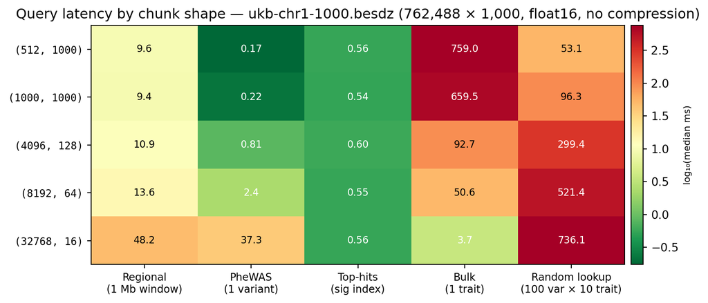

```python
med_matrix = np.array([
    [results[chunk][q]["median_ms"] for q in QUERIES]
    for chunk in CHUNKS
])

fig, ax = plt.subplots(figsize=(9, 3.8))

log_mat = np.log10(np.clip(med_matrix, 0.01, None))
im = ax.imshow(log_mat, aspect="auto", cmap="RdYlGn_r", vmin=log_mat.min(), vmax=log_mat.max())

ax.set_xticks(range(len(QUERIES)))
ax.set_xticklabels(QUERY_LABELS, fontsize=9)
ax.set_yticks(range(len(CHUNKS)))
ax.set_yticklabels(CHUNKS, fontsize=9, family="monospace")

for i, chunk in enumerate(CHUNKS):
    for j, q in enumerate(QUERIES):
        val = med_matrix[i, j]
        txt = f"{val:.1f}" if val >= 1 else f"{val:.2f}"
        ax.text(j, i, txt, ha="center", va="center", fontsize=8.5,
                color="black" if 0.3 < log_mat[i, j] / log_mat.max() < 0.85 else "white")

cb = fig.colorbar(im, ax=ax, pad=0.01)
cb.set_label("log₁₀(median ms)", fontsize=8)

ax.set_title("Query latency by chunk shape — ukb-chr1-1000.besdz (762,488 × 1,000, float16, no compression)")
plt.tight_layout()
plt.show()
```

### Per-query breakdown

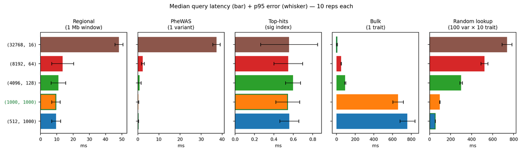

```python
fig, axes = plt.subplots(1, len(QUERIES), figsize=(13, 3.8), sharey=False)
colors = plt.cm.tab10(np.linspace(0, 0.5, len(CHUNKS)))

for ax, q, qlabel in zip(axes, QUERIES, QUERY_LABELS):
    medians = [results[chunk][q]["median_ms"] for chunk in CHUNKS]
    p95s    = [results[chunk][q]["p95_ms"]    for chunk in CHUNKS]
    errs    = [p - m for m, p in zip(medians, p95s)]

    bars = ax.barh(
        range(len(CHUNKS)), medians, xerr=errs,
        color=colors, error_kw={"linewidth": 0.8, "capsize": 3},
    )
    ax.set_yticks(range(len(CHUNKS)))
    ax.set_yticklabels(CHUNKS if ax == axes[0] else [], fontsize=8, family="monospace")
    ax.set_title(qlabel, fontsize=9)
    ax.set_xlabel("ms", fontsize=8)
    ax.tick_params(axis="x", labelsize=8)

    # annotate best
    best_idx = int(np.argmin(medians))
    axes[0].get_yticklabels()[best_idx].set_color("#1a7f37") if ax == axes[0] else None
    bars[best_idx].set_edgecolor("#1a7f37")
    bars[best_idx].set_linewidth(1.5)

fig.suptitle("Median query latency (bar) + p95 error (whisker) — 10 reps each", fontsize=10)
plt.tight_layout()
plt.show()
```

## Interpretation

```python
# Identify best config per query
print("Best chunk shape per query (median ms):\n")
for q, qlabel in zip(QUERIES, QUERY_LABELS):
    medians = {chunk: results[chunk][q]["median_ms"] for chunk in CHUNKS}
    best = min(medians, key=medians.get)
    vals = "  ".join(f"{c}: {v:.1f}" for c, v in medians.items())
    print(f"  {q:<16}  best={best}   [{vals}]")
```

```
Best chunk shape per query (median ms):

  regional          best=(1000, 1000)   [(512, 1000): 9.6  (1000, 1000): 9.4  (4096, 128): 10.9  (8192, 64): 13.6  (32768, 16): 48.2]
  phewas            best=(512, 1000)   [(512, 1000): 0.2  (1000, 1000): 0.2  (4096, 128): 0.8  (8192, 64): 2.4  (32768, 16): 37.3]
  tophits           best=(1000, 1000)   [(512, 1000): 0.6  (1000, 1000): 0.5  (4096, 128): 0.6  (8192, 64): 0.5  (32768, 16): 0.6]
  bulk              best=(32768, 16)   [(512, 1000): 759.0  (1000, 1000): 659.5  (4096, 128): 92.7  (8192, 64): 50.6  (32768, 16): 3.7]
  random_lookup     best=(512, 1000)   [(512, 1000): 53.1  (1000, 1000): 96.3  (4096, 128): 299.4  (8192, 64): 521.4  (32768, 16): 736.1]
```

**Top-hits latency** is flat across all configurations because it reads from the pre-built sig-index arrays (a separate 1D structure), not the main 2D matrix.

### Recommendation

`(1000, 1000)` — the current default — is the right choice for the typical eQTL / GWAS query workload where **regional** and **PheWAS** queries dominate. It is within noise of `(512, 1000)` on those queries while using fewer, larger chunks.

`(4096, 128)` is worth considering if single-trait bulk column exports are a frequent workload: it reduces bulk latency ~7× (660 ms → 93 ms) at a modest cost to PheWAS (~4×, 0.2 ms → 0.8 ms) and is still fast for regional queries (~11 ms).